# Lab 6 assignment

Lucas Parvin

2-17-2024

```r
# Clear Environment
rm(list=ls())

# Load Packages
require(tidyverse)
require(dplyr)
require(pgirmess)
require(ncf)
require(geoR)
require(ggplot2)
require(terra)
require(spatstat)
```

# Background

Researchers set up a square plot with a dimension of 130 m on each side. Within the plot they established blue vane traps in a 5 m grid pattern to sample bee abundance. Every day for 10 days the researchers emptied the blue vane traps and recorded the number of bees collected. After the 10-day sampling period, they calculated the mean daily number of bees captured in the trap each day.

# Challenge 1 (2 points)

Import the blueVanes.csv file from GitHub. Plot the mean bee abundance as a function of the x and y coordinates. Upon initial inspection, does there appear to be spatial dependence in the bee response data?

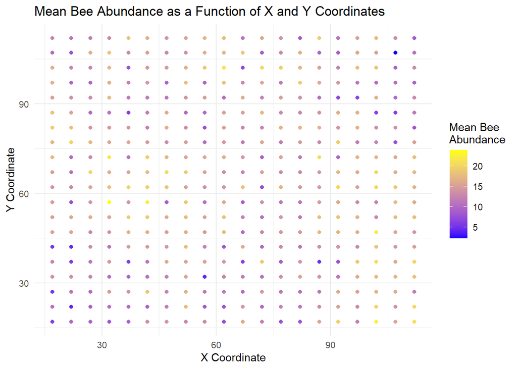

```r
# Load the data
blueVanes <- read.csv("https://raw.githubusercontent.com/ValenteJJ/SpatialEcology/main/Week6/blueVanes.csv")

# Plotting the mean bee abundance as a function of x and y coordinates
ggplot(blueVanes, aes(x = x, y = y, color = meanBee)) +
  geom_point() +
  scale_color_gradient(low = "blue", high = "yellow") +
  labs(title = "Mean Bee Abundance as a Function of X and Y Coordinates",
       x = "X Coordinate",
       y = "Y Coordinate",
       color = "Mean Bee\nAbundance") +
  theme_minimal()
```

**Answer:** Yes, upon initial inspection, there does appear to be spatial dependence in the bee response data. Both high and low mean abundance values appear more clustered than what would be expected if the samples were spatially independent from one another.

# Challenge 2 (3 points)

Empirically test for evidence of spatial dependence in bee abundance by first building a correlogram, then building a semi-variogram. Be sure to provide an envelope for assessing whether the values in each figure are statistically different from what would be expected if the bee values were randomly distributed. Describe the patterns you see, and your interpretation with regards to the spatial dependence in mean bee abundance. Be sure to identify the maximum distance at which you should interpret your figures (2/3 of the maximum distance between points).

#### **Correlogram**

```r
#Create a matrix of distances
coords = cbind(blueVanes$x, blueVanes$y)
colnames(coords) = c('x', 'y')
distMat = as.matrix(dist(coords))

# Set Max Distance
maxDist = (2/3) * max(distMat)

# Create Correlogram
correlogPgirmess = pgirmess::correlog(coords, blueVanes$meanBee, method='Moran', nbclass=26, alternative = 'two.sided') #nbclass=26 because 5m*26=130m
round(correlogPgirmess, 2)
```

```
## Moran I statistic
##       dist.class  coef p.value     n
##  [1,]       7.49  0.25    0.00  2964
##  [2,]      12.46  0.18    0.00  5472
##  [3,]      17.44  0.14    0.00  6392
##  [4,]      22.41  0.10    0.00  7172
##  [5,]      27.39 -0.01    0.64 10880
##  [6,]      32.36 -0.07    0.00  9088
##  [7,]      37.34 -0.08    0.00 11028
##  [8,]      42.31 -0.05    0.00 11688
##  [9,]      47.29 -0.05    0.00 10612
## [10,]      52.26  0.00    0.95 11544
## [11,]      57.24  0.00    0.85  9800
## [12,]      62.21  0.02    0.05 10748
## [13,]      67.19  0.01    0.36 10688
## [14,]      72.16  0.01    0.31  8752
## [15,]      77.14 -0.02    0.30  8052
## [16,]      82.11 -0.08    0.00  6360
## [17,]      87.09 -0.07    0.00  6568
## [18,]      92.06 -0.10    0.00  4468
## [19,]      97.04 -0.04    0.19  3256
## [20,]     102.01  0.05    0.16  1776
## [21,]     106.99  0.19    0.00   900
## [22,]     111.96  0.18    0.00   832
## [23,]     116.94  0.24    0.00   280
## [24,]     121.91  0.18    0.05   220
## [25,]     126.89  0.14    0.39    40
## [26,]     131.86  0.08    0.56    20
```

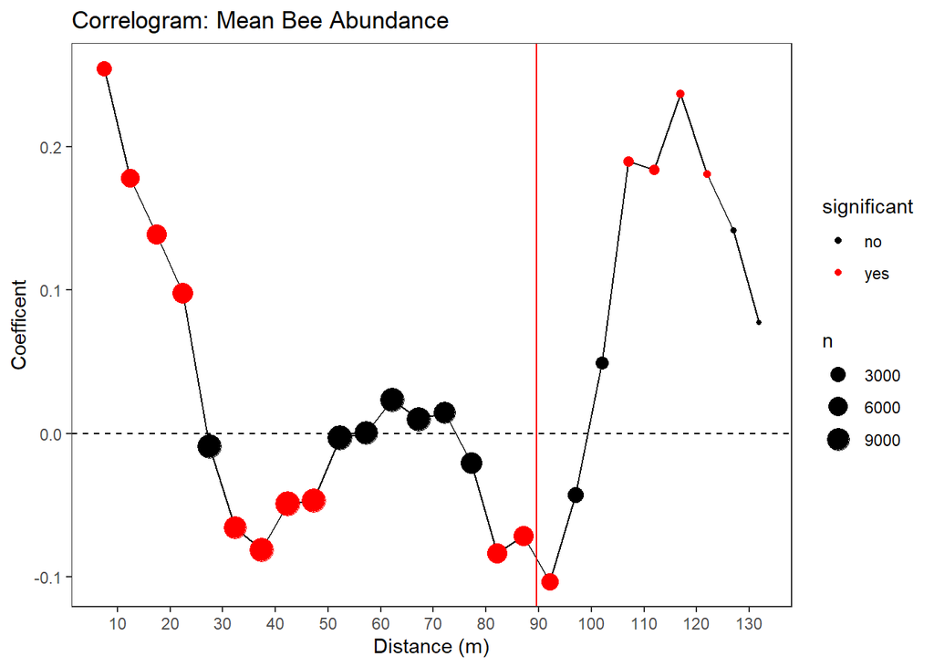

```r
# Plot Correlogram
tmp = data.frame(correlogPgirmess) %>%
  mutate(significant = ifelse(p.value < 0.05, 'yes', 'no')) # <-- In Place of Envelope

ggplot(tmp, aes(x=dist.class, y=coef))+
  geom_line()+
  geom_point(aes(color=significant, size=n))+
  scale_color_manual(values=c('black', 'red'))+
  theme_bw()+
  theme(panel.grid=element_blank())+
  geom_hline(yintercept=0, linetype='dashed')+
  geom_vline(xintercept=maxDist, color='red')+
  scale_x_continuous(breaks=seq(0, 130, 10)) +
  labs(title = "Correlogram: Mean Bee Abundance",
       x = "Distance (m)",
       y = "Coefficent")
```

**Answer:** Given that statistically significant differences (from what would be expected if the bee values were randomly distributed) are designated by red and black points, an envelope is not needed in this correlogram. This correlogram demonstrates positive spatial dependence among bee abundance within 20 m. It also demonstrates less intense significant negative spatial dependence between ~30-50 m and ~80-90 m. The max distance between two points is `max(distMat)` = 134.3503, so the maximum distance at which I am interpreting my figures is `(2/3)*134.3503` = 89.56686. Overall, the correlogram has a wave-like pattern, hinting at spatial dependence with positive and negative influences on bee abundance at different distances.

#### **Semi-Variogram**

```r
# Prepare geoR object
geoBee = as.geodata(blueVanes)

# Build Variogram
empGeor = variog(geoBee, max.dist=maxDist, breaks=seq(0, maxDist, by=5))
```

```
## variog: computing omnidirectional variogram
```

```r
plot(empGeor)

empEnv = variog.mc.env(geoBee, obj.var=empGeor, nsim=99)
```

```
## variog.env: generating 99 simulations by permutating data values
## variog.env: computing the empirical variogram for the 99 simulations
## variog.env: computing the envelops
```

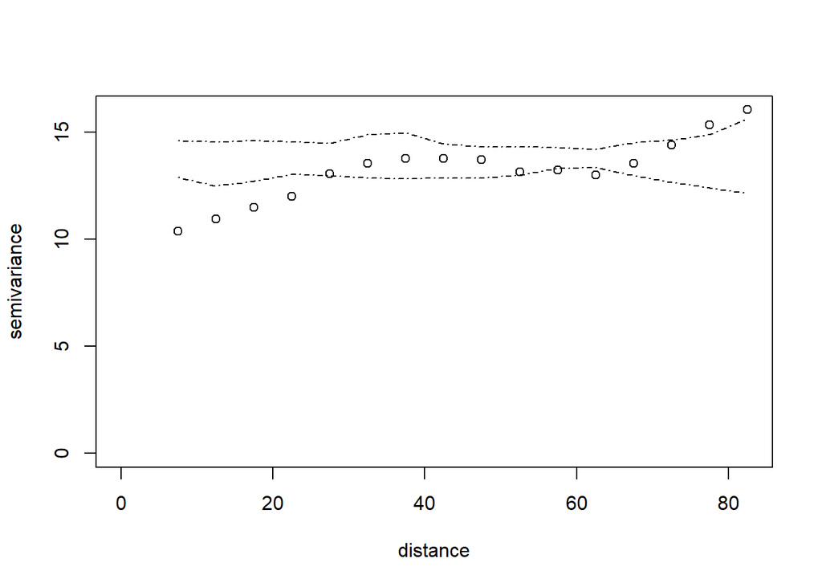

```r
plot(empGeor, envelope=empEnv)
```

**Answer:** This semi-variogram demonstrates significant spatial covariance between bee abundances at blue vanes within ~25 m of one another – determined by where the points fall outside of the envelope. Additionally, variance between points ~75-90 m away from one another are significantly greater than what would be expected for a random distribution of bee abundances. This semi-variogram is limited to 2/3 of the maximum distance, ~89.6 m.

#### **Testing Model AIC Values Against CSR**

```r
# Create Exponential Model
mlExp = likfit(geoBee, cov.model='exp', ini=c(7, 60))
```

```
## kappa not used for the exponential correlation function
## ---------------------------------------------------------------
## likfit: likelihood maximisation using the function optim.
## likfit: Use control() to pass additional
##          arguments for the maximisation function.
##         For further details see documentation for optim.
## likfit: It is highly advisable to run this function several
##         times with different initial values for the parameters.
## likfit: WARNING: This step can be time demanding!
## ---------------------------------------------------------------
## likfit: end of numerical maximisation.
```

```r
# Create Spherical Model
mlSph = likfit(geoBee, cov.model='sph', ini=c(7, 60))
```

```
## kappa not used for the spherical correlation function
## ---------------------------------------------------------------
## likfit: likelihood maximisation using the function optim.
## likfit: Use control() to pass additional
##          arguments for the maximisation function.
##         For further details see documentation for optim.
## likfit: It is highly advisable to run this function several
##         times with different initial values for the parameters.
## likfit: WARNING: This step can be time demanding!
## ---------------------------------------------------------------
## likfit: end of numerical maximisation.
```

```r
# Print AIC Values for Spatial & Non-spatial Models
print(paste("AIC Value of Exponential Model:", mlExp$AIC))
```

```
## [1] "AIC Value of Exponential Model: 2117.78840620512"
```

```r
print(paste("AIC Value of Spherical Model:", mlSph$AIC))
```

```
## [1] "AIC Value of Spherical Model: 2112.46607831613"
```

```r
print(paste("AIC Value of Non-Spatial Model:", 2186)) # <-- Same in Both Model Lists
```

```
## [1] "AIC Value of Non-Spatial Model: 2186"
```

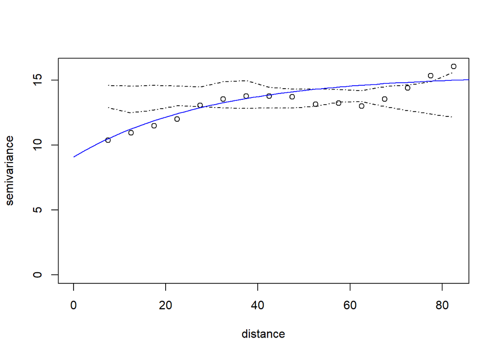

```r
plot(empGeor, envelope=empEnv)
lines(mlExp, col='blue')
```

*Overall, the correlogram, semi-variogram, and comparison of AIC values demonstrate that mean bee abundance is spatially dependent. However, the exact scale or pattern of dependence – and the mechanism for this spatial dependence is still unknown.*

# Challenge 3 (4 points)

Fit a simple linear model (assuming a normally distributed error term) that models mean bee abundance as a function of an intercept only (no other covariates in the model). Compare the model-estimated intercept to the bee abundance values averaged across all sites. What do you notice?

Empirically test for evidence of spatial autocorrelation IN THE MODEL RESIDUALS by first building a correlogram, then building a semi-variogram. Be sure to provide an envelope for assessing whether the values in each figure are statistically different from what would be expected if the bee values were randomly distributed in space. Compare these figures to those built for the raw data. What similarities or differences to you notice?

#### **Comparing Linear Model Intercept to Mean Bee Abundance**

```r
# Fit a simple linear model with an intercept only
linearmodel <- lm(meanBee ~ 1, data = blueVanes)
summary(linearmodel)
```

```
##
## Call:
## lm(formula = meanBee ~ 1, data = blueVanes)
##
## Residuals:
##      Min       1Q   Median       3Q      Max
## -11.7427  -2.5411   0.3501   2.5858   9.9204
##
## Coefficients:
##             Estimate Std. Error t value Pr(>|t|)
## (Intercept)  13.9322     0.1852   75.22   <2e-16 ***
## ---
## Signif. codes:  0 '***' 0.001 '**' 0.01 '*' 0.05 '.' 0.1 ' ' 1
##
## Residual standard error: 3.704 on 399 degrees of freedom
```

```r
# Compare the model-estimated intercept to the average bee abundance across all sites
average_bee_abundance <- mean(blueVanes$meanBee)

# Print the model-estimated intercept and the average bee abundance
model_intercept <- coef(linearmodel)[1] # Extracting the intercept from the model coefficients
print(paste("Model-estimated intercept:", model_intercept))
```

```
## [1] "Model-estimated intercept: 13.9322039180302"
```

```r
print(paste("Average bee abundance across all sites:", average_bee_abundance))
```

```
## [1] "Average bee abundance across all sites: 13.9322039180302"
```

**Answer:** The model-estimated intercept and the mean bee abundance are the exact same. This is because the intercept in an intercept-only model represents the mean of the dependent variable (since no other explanatory variables are included), which in this case, is the mean bee abundance across all points.

#### **Correlogram: Simple Linear Model Residuals**

```r
# Linear model residuals
linearmodel_residuals <- residuals(linearmodel)

# Create new data frame with linear model residuals in place of bee abundance column
blueVaneslm = blueVanes
blueVaneslm = blueVanes[,-3]
blueVaneslm$linearmodel_residuals = linearmodel_residuals

# Create Correlogram
correlogPgirmess_lmresid = pgirmess::correlog(coords, blueVaneslm$linearmodel_residuals, method='Moran', nbclass=26, alternative = 'two.sided') #nbclass=26 because 5m*26=130m
round(correlogPgirmess_lmresid, 2)
```

```
## Moran I statistic
##       dist.class  coef p.value     n
##  [1,]       7.49  0.25    0.00  2964
##  [2,]      12.46  0.18    0.00  5472
##  [3,]      17.44  0.14    0.00  6392
##  [4,]      22.41  0.10    0.00  7172
##  [5,]      27.39 -0.01    0.64 10880
##  [6,]      32.36 -0.07    0.00  9088
##  [7,]      37.34 -0.08    0.00 11028
##  [8,]      42.31 -0.05    0.00 11688
##  [9,]      47.29 -0.05    0.00 10612
## [10,]      52.26  0.00    0.95 11544
## [11,]      57.24  0.00    0.85  9800
## [12,]      62.21  0.02    0.05 10748
## [13,]      67.19  0.01    0.36 10688
## [14,]      72.16  0.01    0.31  8752
## [15,]      77.14 -0.02    0.30  8052
## [16,]      82.11 -0.08    0.00  6360
## [17,]      87.09 -0.07    0.00  6568
## [18,]      92.06 -0.10    0.00  4468
## [19,]      97.04 -0.04    0.19  3256
## [20,]     102.01  0.05    0.16  1776
## [21,]     106.99  0.19    0.00   900
## [22,]     111.96  0.18    0.00   832
## [23,]     116.94  0.24    0.00   280
## [24,]     121.91  0.18    0.05   220
## [25,]     126.89  0.14    0.39    40
## [26,]     131.86  0.08    0.56    20
```

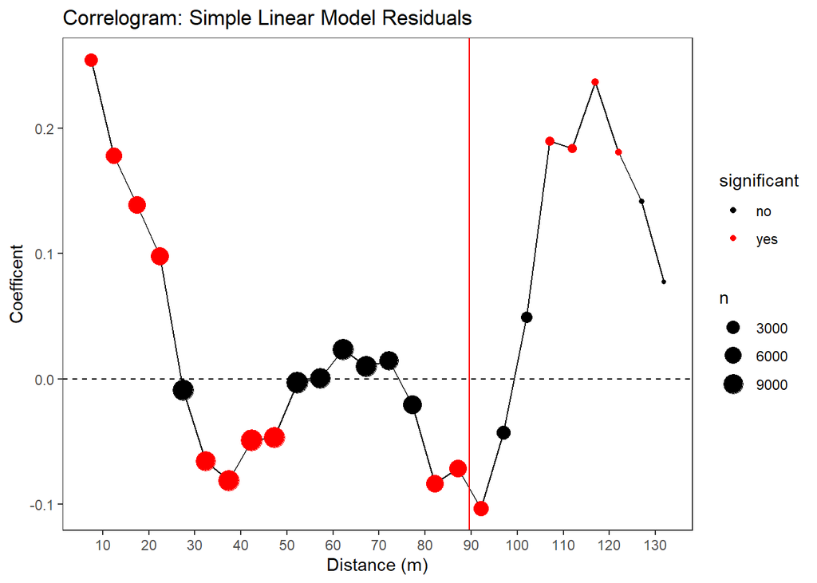

```r
# Plot Correlogram
tmp2 = data.frame(correlogPgirmess_lmresid) %>%
  mutate(significant = ifelse(p.value < 0.05, 'yes', 'no')) # <-- In Place of Envelope

ggplot(tmp2, aes(x=dist.class, y=coef))+
  geom_line()+
  geom_point(aes(color=significant, size=n))+
  scale_color_manual(values=c('black', 'red'))+
  theme_bw()+
  theme(panel.grid=element_blank())+
  geom_hline(yintercept=0, linetype='dashed')+
  geom_vline(xintercept=maxDist, color='red')+
  scale_x_continuous(breaks=seq(0, 130, 10)) +
    labs(title = "Correlogram: Simple Linear Model Residuals",
       x = "Distance (m)",
       y = "Coefficent")
```

**Answer:** The correlogram for the model residuals looks exactly the same as the correlogram for the raw data. This is because the residuals have a constant relationship with the mean abundance values. Thus, the abundance values between two points (A & B), separated by X meters, will have the exact same spatial autocorrelation to one another as the residuals for points A & B, separated by X meters. I am interpreting this correlogram at a maximum distance of ~89.6, and again, no envelope was needed given that significance is differentiated with the color of plotted points.

#### **Semi-Variogram: Simple Linear Model Residuals**

```r
# Build geoR object
geoBeelm = as.geodata(blueVaneslm)

# Build Variogram
empGeorlm = variog(geoBeelm, max.dist=maxDist, breaks=seq(0, maxDist, by=5))
```

```
## variog: computing omnidirectional variogram
```

```r
empEnvlm = variog.mc.env(geoBeelm, obj.var=empGeorlm, nsim=99)
```

```
## variog.env: generating 99 simulations by permutating data values
## variog.env: computing the empirical variogram for the 99 simulations
## variog.env: computing the envelops
```

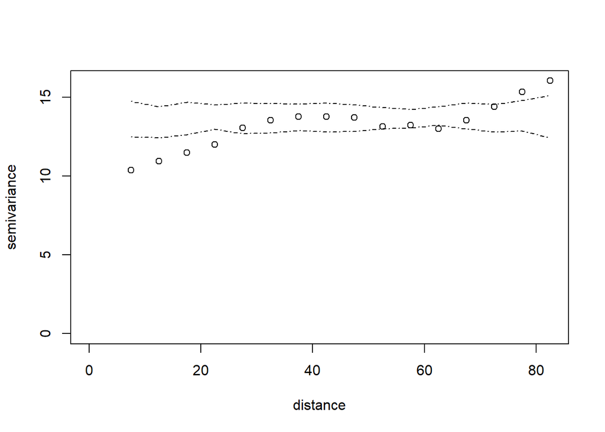

```r
#Plot
plot(empGeorlm, envelope=empEnvlm)
```

**Answer:** This semi-variogram, limited to the same maximum distance of ~89.6 m, looks exactly the same as the semi-variogram plotted for the raw data. Like the one built for the raw data, it demonstrates significant spatial covariance between bee abundance RESIDUALS (rather than bee abundance) at blue vanes within ~25 m of one another. Again, variance between points ~75-90 m away from one another are significantly greater than what would be expected for a random distribution.

# Challenge 4 (4 points)

Conventional wisdom indicates that the distribution of floral resources may substantially influence bee abundance. In addition, I am completely making up the following fact: the average bee has a perceptual range of about 15 m. Below I have provided code for importing a raster that shows the number of flowers counted in 1 m grid cells across the entire study area. Use the focal() function from the previous lab to generate a new raster in which each cell value represents the mean number of flowers in cells within a 15 m radius. Plot the distribution of the blue vane traps over the 15 m focal raster. No text required here, just show me the plot.

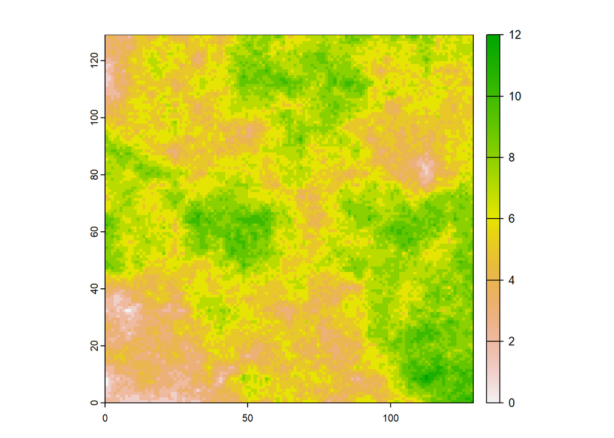

```r
# Load and View Raster
floral = rast('https://github.com/ValenteJJ/SpatialEcology/raw/main/Week6/floralResources.tif')
plot(floral)
```

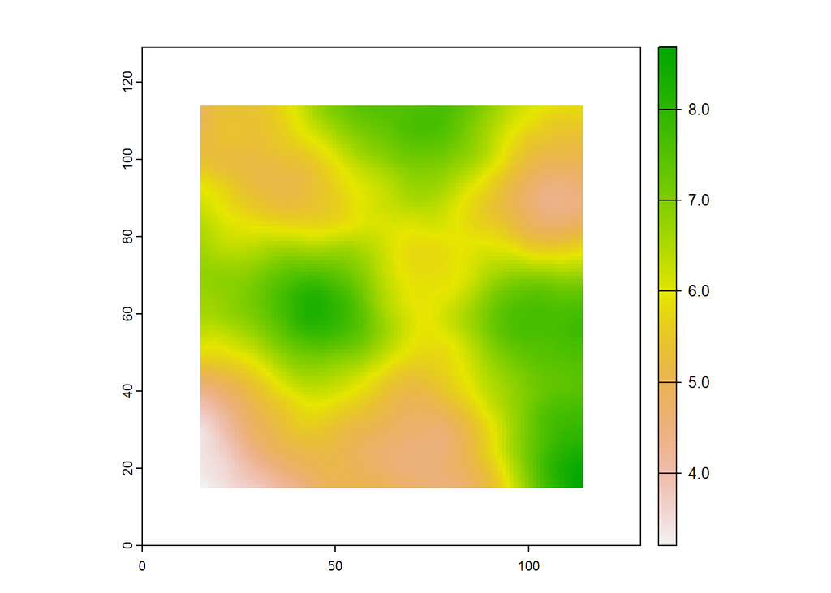

```r
# Generate New Raster
newraster = focalMat(floral, 15, type='circle', fillNA=FALSE)

# Plot New Flower Distribution
FlowerDistribution = focal(floral, w = newraster, fun='sum')
plot(FlowerDistribution)
```

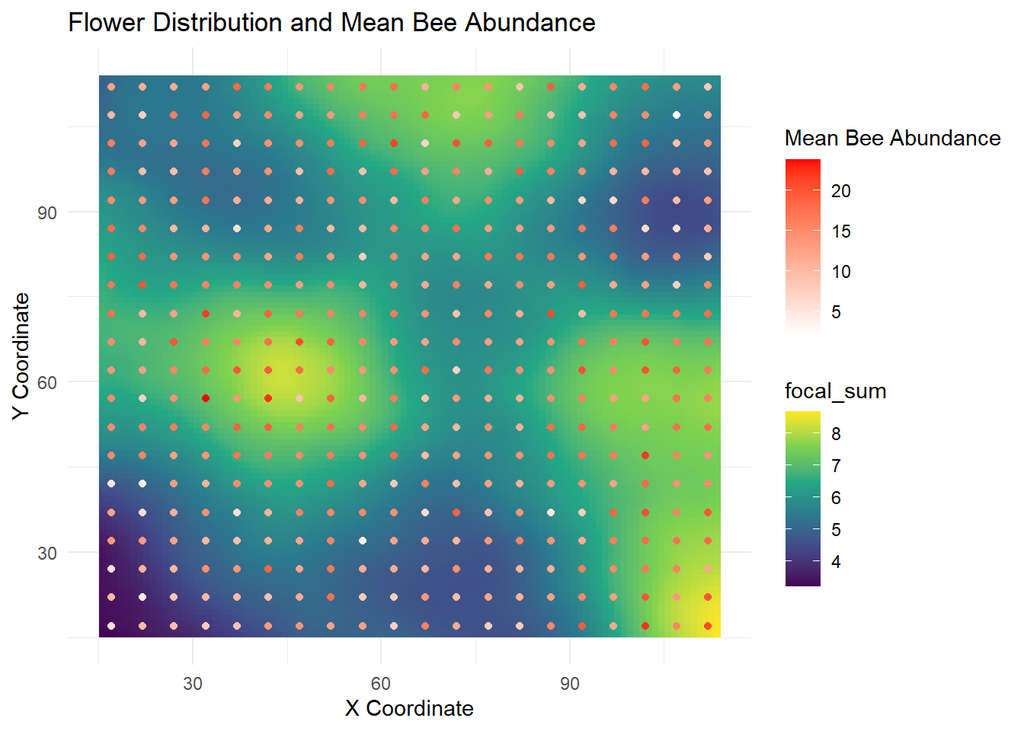

```r
# Convert Flower Distribution to Dataframe for ggplot2
FlowerDistribution_df <- as.data.frame(FlowerDistribution, xy = TRUE)

# Plot with ggplot2
ggplot() +
  geom_raster(data = FlowerDistribution_df, aes(x = x, y = y, fill = focal_sum)) +
  geom_point(data = blueVanes, aes(x = x, y = y, color = meanBee)) +
  scale_fill_viridis_c() +
  scale_color_gradient(low = "white", high = "red", name = "Mean Bee Abundance") +
  labs(title = "Flower Distribution and Mean Bee Abundance",
       x = "X Coordinate", y = "Y Coordinate") +
  theme_minimal()
```

# Challenge 5 (4 points)

Extract the focal flower value from the raster you just created at each point using the extract() function. You now have an estimate for the average number of flowers per meter around each blue vane trap. Fit a second linear model, but this time include average floral abundance within 15 m as a covariate. Export the residuals from this fitted model, and again, examine a correlogram and variogram of the residuals. As always, be sure to plot random envelopes. Now what do you notice?

```r
# Setting Up Model
blueVaneCoords = blueVanes[,-3]
flowerextraction = extract(FlowerDistribution, blueVaneCoords)
blueVanes$meanflowers = flowerextraction$focal_sum
linearmodel_floral_covar <- lm(meanBee ~ meanflowers, data = blueVanes)

# Floral Linear Model Residuals
linearmodel_floral_covar_residuals <- residuals(linearmodel_floral_covar)

# Create new data frame with linear model residuals in place of bee abundance column
blueVaneslm_floral = blueVanes
blueVaneslm_floral$linearmodel_residuals_floral = linearmodel_floral_covar_residuals

# Create Correlogram
lmresidual_correlog_floral <- pgirmess::correlog(coords, blueVaneslm_floral$linearmodel_residuals_floral, method='Moran', nbclass=26, alternative = 'two.sided')
round(lmresidual_correlog_floral, 2)
```

```
## Moran I statistic
##       dist.class  coef p.value     n
##  [1,]       7.49 -0.02    0.61  2964
##  [2,]      12.46 -0.04    0.05  5472
##  [3,]      17.44  0.00    0.85  6392
##  [4,]      22.41  0.03    0.05  7172
##  [5,]      27.39  0.00    0.77 10880
##  [6,]      32.36 -0.01    0.82  9088
##  [7,]      37.34 -0.01    0.38 11028
##  [8,]      42.31  0.00    0.89 11688
##  [9,]      47.29 -0.02    0.24 10612
## [10,]      52.26  0.02    0.07 11544
## [11,]      57.24  0.00    0.93  9800
## [12,]      62.21  0.00    0.69 10748
## [13,]      67.19 -0.01    0.44 10688
## [14,]      72.16  0.01    0.36  8752
## [15,]      77.14  0.02    0.19  8052
## [16,]      82.11 -0.02    0.34  6360
## [17,]      87.09  0.01    0.53  6568
## [18,]      92.06 -0.05    0.10  4468
## [19,]      97.04 -0.02    0.67  3256
## [20,]     102.01 -0.01    0.98  1776
## [21,]     106.99  0.06    0.18   900
## [22,]     111.96 -0.01    0.89   832
## [23,]     116.94  0.04    0.57   280
## [24,]     121.91  0.03    0.60   220
## [25,]     126.89  0.11    0.47    40
## [26,]     131.86 -0.37    0.35    20
```

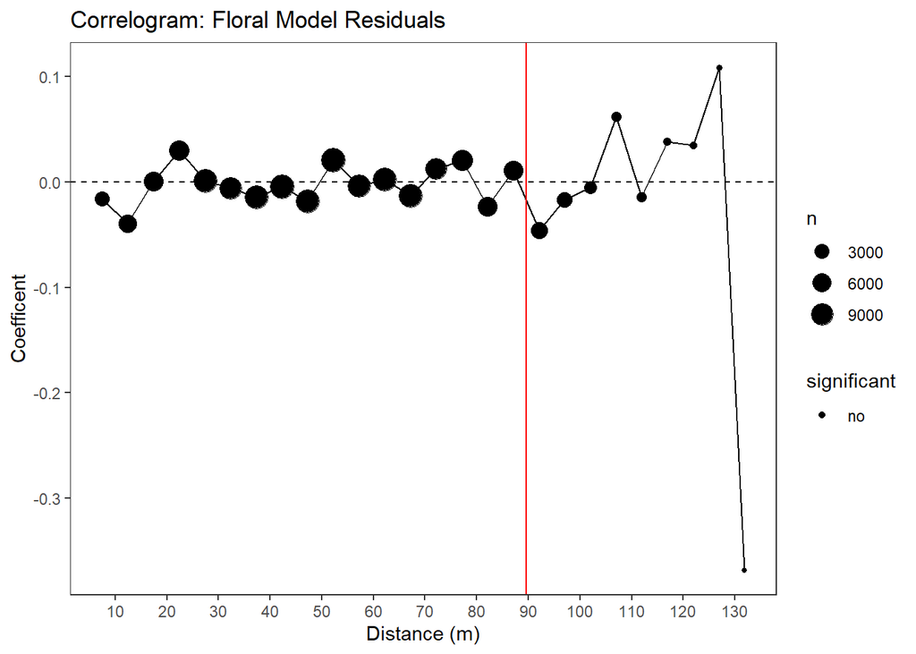

```r
# Plot Correlogram
tmp3 = data.frame(lmresidual_correlog_floral) %>%
  mutate(significant = ifelse(p.value < 0.05, 'yes', 'no')) # <-- In Place of Envelope

ggplot(tmp3, aes(x=dist.class, y=coef))+
  geom_line()+
  geom_point(aes(color=significant, size=n))+
  scale_color_manual(values=c('black', 'red'))+
  theme_bw()+
  theme(panel.grid=element_blank())+
  geom_hline(yintercept=0, linetype='dashed')+
  geom_vline(xintercept=maxDist, color='red')+
  scale_x_continuous(breaks=seq(0, 130, 10)) +
    labs(title = "Correlogram: Floral Model Residuals",
       x = "Distance (m)",
       y = "Coefficent")
```

**Answer:** After accounting for the distribution of floral resources as an explanatory variable in the model, we see that there is essentially no spatial autocorrelation at any distance. Every point within the maximum distance of inference (~89.6 m) is near zero and designated as not significantly different from what would be expected in a completely random distribution of bee abundance values.

```r
# Build geoR object
blueVaneslm2 = blueVaneslm_floral[,-c(3,4)]
geoBeelm2 = as.geodata(blueVaneslm2)

# Build Variogram
empGeorlm2 = variog(geoBeelm2, max.dist=maxDist, breaks=seq(0, maxDist, by=5))
```

```
## variog: computing omnidirectional variogram
```

```r
empEnvlm2 = variog.mc.env(geoBeelm2, obj.var=empGeorlm2, nsim=99)
```

```
## variog.env: generating 99 simulations by permutating data values
## variog.env: computing the empirical variogram for the 99 simulations
## variog.env: computing the envelops
```

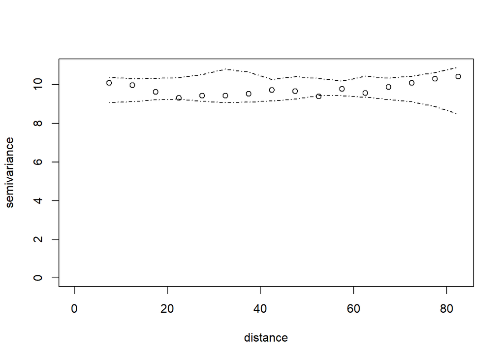

```r
#Plot
plot(empGeorlm2, envelope=empEnvlm2)
```

**Answer:** Mirroring findings from the correlogram above, variance across all distances of interest appears essentially no different from what would be expected in a completely random distribution of bee abundance values, after accounting for the distribution of floral resources as an explanatory variable.

# Challenge 6 (3 points)

What is your assessment regarding the distribution of bee abundance in this study area? Does it exhibit spatial dependence, and if so, what is driving that pattern?

**Answer:** Bee abundance appears driven by density of floral resources. In this way, bees are exhibiting spatial dependence on flowers, but not on each other. This is demonstrated by the fact that the autocorrelation and variance among residuals for bee abundance appear totally random after accounting for density of floral resources in the model.